# Analysis of Airbnb listings in New York City

Presented by : Radhika Rajeevan | Sunit Nair

1. Objective
2. Data Gathering
3. Data Splitting and Cleaning
   - 3.1 Property Host Information
   - 3.2. Property Location Information
   - 3.3 Property Information
   - 3.4 Review Information
   - 3.5. Price Information
4. Merging
5. Exploratory Data Analysis
   - 5.1 Distribution of Price
   - 5.2 Price vs Neighbourhood
   - 5.3 Price vs Property Type
   - 5.4 Price vs Room Type
   - 5.5 Neighbourhood vs Review
   - 5.6 Price vs Reviews
   - 5.7 Price vs Amenities
   - 5.8 Price vs Occupancy
6. Conclusion of Exploratory

## 1. Objective

This analysis intends to provide recommendations to a prospective tenant who wishes to decide upon an appropriate property to rent given a set of preferences like location, capacity of occupancy, number of days to rent etc.

Alternately , this analysis also helps in understanding the pricing trend of properties on Airbnb which provides information to rental property owners who would potentially wish to sublet on Airbnb in New York City.

```python
# importing libraries
import pandas as pd
import matplotlib.pyplot as plt
import seaborn as sns

#ignore warnings
import sys
if not sys.warnoptions:
    import warnings
    warnings.simplefilter("ignore")
```

## 2. Data Gathering

Data is sourced from Kaggle

```python
#reading csv file from desktop

loc = r'C:\Users\Radhika\Anaconda3\AML Project\\'
filename = 'NewYorkCityDataSet.xlsx'
df_Airbnb = pd.read_excel(loc+filename)
#print(loc+filename)
```

```python
#preview of data types

df_Airbnb.dtypes
```

```
ID                                         int64
Listing Url                               object
Scrape ID                                  int64
Last Scraped                      datetime64[ns]
Name                                      object
Summary                                   object
Space                                     object
Description                               object
Experiences Offered                       object
Neighborhood Overview                     object
Notes                                     object
Transit                                   object
Access                                    object
Interaction                               object
House Rules                               object
Thumbnail Url                             object
Medium Url                                object
Picture Url                               object
XL Picture Url                            object
Host ID                                    int64
Host URL                                  object
Host Name                                 object
Host Since                        datetime64[ns]
Host Location                             object
Host About                                object
Host Response Time                        object
Host Response Rate                       float64
Host Acceptance Rate                     float64
Host Thumbnail Url                        object
Host Picture Url                          object
                                       ...
Security Deposit                         float64
Cleaning Fee                             float64
Guests Included                            int64
Extra People                               int64
Minimum Nights                             int64
Maximum Nights                             int64
Calendar Updated                          object
Has Availability                         float64
Availability 30                            int64
Availability 60                            int64
Availability 90                            int64
Availability 365                           int64
Calendar last Scraped             datetime64[ns]
Number of Reviews                          int64
First Review                      datetime64[ns]
Last Review                       datetime64[ns]
Review Scores Rating                     float64
Review Scores Accuracy                   float64
Review Scores Cleanliness                float64
Review Scores Checkin                    float64
Review Scores Communication              float64
Review Scores Location                   float64
Review Scores Value                      float64
License                                  float64
Jurisdiction Names                        object
Cancellation Policy                       object
Calculated host listings count             int64
Reviews per Month                        float64
Geolocation                               object
Features                                  object
Length: 89, dtype: object
```

```python
#number of rows and columns of raw data
df_Airbnb.shape
```

```
(19528, 89)
```

```python
#preview of raw data
df_Airbnb.head()
```

|  | ID | Listing Url | Scrape ID | Last Scraped | Name | Summary | Space | Description | Experiences Offered | Neighborhood Overview | ... | Review Scores Communication | Review Scores Location | Review Scores Value | License | Jurisdiction Names | Cancellation Policy | Calculated host listings count | Reviews per Month | Geolocation | Features |
| --- | --- | --- | --- | --- | --- | --- | --- | --- | --- | --- | --- | --- | --- | --- | --- | --- | --- | --- | --- | --- | --- |
| 0 | 17938814 | https://www.airbnb.com/rooms/17938814 | 20170502132028 | 2017-05-05 | Beautiful spacious one bedroom, upper east side | This apartment is flooded with light. It is 2 ... | NaN | This apartment is flooded with light. It is 2 ... | none | NaN | ... | 9.0 | 10.0 | 10.0 | NaN | NaN | flexible | 1 | 3.00 | 40.7462341736, -73.9569527785 | Host Has Profile Pic,Is Location Exact,Instant... |
| 1 | 267561 | https://www.airbnb.com/rooms/267561 | 20170502132028 | 2017-05-05 | Sun filled Lower East Side 1 BR apt | NaN | Amazing location and always super clean! Stay ... | Amazing location and always super clean! Stay ... | none | NaN | ... | 10.0 | 10.0 | 10.0 | NaN | NaN | moderate | 1 | 0.14 | 40.7207796059, -73.9864214862 | Host Has Profile Pic,Is Location Exact |
| 2 | 16301717 | https://www.airbnb.com/rooms/16301717 | 20170502132028 | 2017-05-05 | Room in Prime LES location | My place is close to Clinton St. Baking Compan... | NaN | My place is close to Clinton St. Baking Compan... | none | NaN | ... | NaN | NaN | NaN | NaN | NaN | flexible | 1 | 0.20 | 40.7209392264, -73.9831050977 | Host Has Profile Pic,Host Identity Verified,Is... |
| 3 | 834190 | https://www.airbnb.com/rooms/834190 | 20170502132028 | 2017-05-04 | Manhattan Luxury Loft.Like.Love.Lots.Look !! | Welcome to downtown, simply the best part of M... | Downtown Manhattan, .. just like you see it in... | Welcome to downtown, simply the best part of M... | none | Best neighborhood in Manhattan for independent... | ... | 10.0 | 10.0 | 10.0 | NaN | NaN | strict | 1 | 125.92 | 40.7192118485, -73.9911591807 | Host Is Superhost,Host Has Profile Pic,Host Id... |
| 4 | 15582736 | https://www.airbnb.com/rooms/15582736 | 20170502132028 | 2017-05-05 | LES Private Room - NYC Manhattan Location | Perfectly located on the border of the Lower E... | The space is a your typical New York two-bedro... | Perfectly located on the border of the Lower E... | none | NaN | ... | 10.0 | 10.0 | 10.0 | NaN | NaN | strict | 1 | 0.17 | 40.7201315734, -73.9836733593 | Host Has Profile Pic,Host Identity Verified,Is... |

5 rows × 89 columns

```python
#listing columns
df_Airbnb.columns
```

```
Index(['ID', 'Listing Url', 'Scrape ID', 'Last Scraped', 'Name', 'Summary',
       'Space', 'Description', 'Experiences Offered', 'Neighborhood Overview',
       'Notes', 'Transit', 'Access', 'Interaction', 'House Rules',
       'Thumbnail Url', 'Medium Url', 'Picture Url', 'XL Picture Url',
       'Host ID', 'Host URL', 'Host Name', 'Host Since', 'Host Location',
       'Host About', 'Host Response Time', 'Host Response Rate',
       'Host Acceptance Rate', 'Host Thumbnail Url', 'Host Picture Url',
       'Host Neighbourhood', 'Host Listings Count',
       'Host Total Listings Count', 'Host Verifications', 'Street',
       'Neighbourhood', 'Neighbourhood Cleansed',
       'Neighbourhood Group Cleansed', 'City', 'State', 'Zipcode', 'Market',
       'Smart Location', 'Country Code', 'Country', 'Latitude', 'Longitude',
       'Property Type', 'Room Type', 'Accommodates', 'Bathrooms', 'Bedrooms',
       'Beds', 'Bed Type', 'Amenities', 'Square Feet', 'Price', 'Weekly Price',
       'Monthly Price', 'Security Deposit', 'Cleaning Fee', 'Guests Included',
       'Extra People', 'Minimum Nights', 'Maximum Nights', 'Calendar Updated',
       'Has Availability', 'Availability 30', 'Availability 60',
       'Availability 90', 'Availability 365', 'Calendar last Scraped',
       'Number of Reviews', 'First Review', 'Last Review',
       'Review Scores Rating', 'Review Scores Accuracy',
       'Review Scores Cleanliness', 'Review Scores Checkin',
       'Review Scores Communication', 'Review Scores Location',
       'Review Scores Value', 'License', 'Jurisdiction Names',
       'Cancellation Policy', 'Calculated host listings count',
       'Reviews per Month', 'Geolocation', 'Features'],
      dtype='object')
```

```python
#creating a copy of data to work with chunks

df_Airbnb_raw = df_Airbnb.copy()
```

```python
df_Airbnb_raw.shape
```

```
(19528, 89)
```

```python
df_Airbnb_raw.columns
```

```
Index(['ID', 'Listing Url', 'Scrape ID', 'Last Scraped', 'Name', 'Summary',
       'Space', 'Description', 'Experiences Offered', 'Neighborhood Overview',
       'Notes', 'Transit', 'Access', 'Interaction', 'House Rules',
       'Thumbnail Url', 'Medium Url', 'Picture Url', 'XL Picture Url',
       'Host ID', 'Host URL', 'Host Name', 'Host Since', 'Host Location',
       'Host About', 'Host Response Time', 'Host Response Rate',
       'Host Acceptance Rate', 'Host Thumbnail Url', 'Host Picture Url',
       'Host Neighbourhood', 'Host Listings Count',
       'Host Total Listings Count', 'Host Verifications', 'Street',
       'Neighbourhood', 'Neighbourhood Cleansed',
       'Neighbourhood Group Cleansed', 'City', 'State', 'Zipcode', 'Market',
       'Smart Location', 'Country Code', 'Country', 'Latitude', 'Longitude',
       'Property Type', 'Room Type', 'Accommodates', 'Bathrooms', 'Bedrooms',
       'Beds', 'Bed Type', 'Amenities', 'Square Feet', 'Price', 'Weekly Price',
       'Monthly Price', 'Security Deposit', 'Cleaning Fee', 'Guests Included',
       'Extra People', 'Minimum Nights', 'Maximum Nights', 'Calendar Updated',
       'Has Availability', 'Availability 30', 'Availability 60',
       'Availability 90', 'Availability 365', 'Calendar last Scraped',
       'Number of Reviews', 'First Review', 'Last Review',
       'Review Scores Rating', 'Review Scores Accuracy',
       'Review Scores Cleanliness', 'Review Scores Checkin',
       'Review Scores Communication', 'Review Scores Location',
       'Review Scores Value', 'License', 'Jurisdiction Names',
       'Cancellation Policy', 'Calculated host listings count',
       'Reviews per Month', 'Geolocation', 'Features'],
      dtype='object')
```

## 3. Splitting data into chunks

1. Host info
2. Location info
3. Property info
4. Review info
5. Price info

### 3.1. Property Host Information : Removing NA and formating

```python
#manually grouping data by features

host_info = ['ID','Host ID','Host Since','Host Response Time','Host Response Rate','Host Neighbourhood','Host Listings Count']
loc_info = ['ID','Transit','Access','Neighbourhood Cleansed','Neighbourhood Group Cleansed','Zipcode','Latitude','Longitude','Geolocation']
property_info = ['ID','Property Type','Room Type','Accommodates','Bathrooms','Bedrooms','Beds','Bed Type','Amenities','Square Feet','Price','Security Deposit','Cleaning Fee','Guests Included','Extra People','Minimum Nights','Maximum Nights','Cancellation Policy']
review_info = ['ID','Number of Reviews','First Review','Last Review','Review Scores Rating','Review Scores Accuracy','Review Scores Cleanliness','Review Scores Checkin','Review Scores Communication','Review Scores Location','Review Scores Value','Reviews per Month','Features']
price_info = ['ID','Price','Weekly Price','Monthly Price']
```

```python
#information about the property host : 19528 observations and 7 features
df_host = df_Airbnb_raw[host_info]
print(df_host.shape)
df_host.head()
```

```
(19528, 7)
```

|  | ID | Host ID | Host Since | Host Response Time | Host Response Rate | Host Neighbourhood | Host Listings Count |
| --- | --- | --- | --- | --- | --- | --- | --- |
| 0 | 17938814 | 55199493 | 2016-01-18 | within an hour | 100.0 | Long Island City | 1.0 |
| 1 | 267561 | 1403098 | 2011-11-13 | NaN | NaN | Lower East Side | 1.0 |
| 2 | 16301717 | 14256846 | 2014-04-14 | within a day | 86.0 | Lower East Side | 1.0 |
| 3 | 834190 | 2369681 | 2012-05-14 | within an hour | 100.0 | Lower East Side | 1.0 |
| 4 | 15582736 | 2167563 | 2012-04-18 | NaN | NaN | Lower East Side | 1.0 |

```python
# checking the unique values of Host Response Time

df_host['Host Response Time'].unique()
```

```
array(['within an hour', nan, 'within a day', 'within a few hours',
       'a few days or more'], dtype=object)
```

```python
# value counts : null and unique values of Response Time

print(df_host['Host Response Time'].isna().sum())
print(df_host['Host Response Time'].value_counts())
```

```
6392
within an hour        5648
within a few hours    3675
within a day          3155
a few days or more     658
Name: Host Response Time, dtype: int64
```

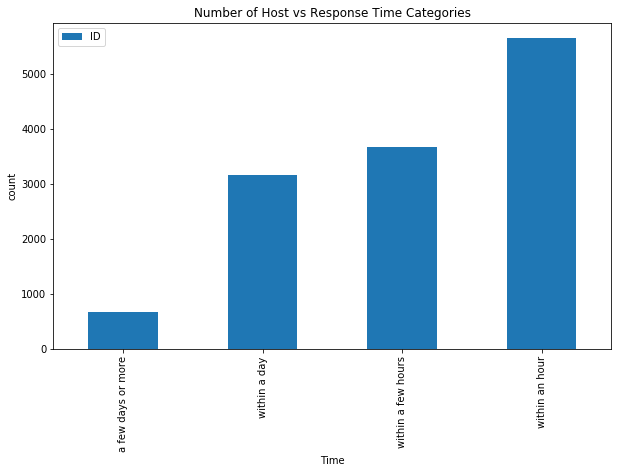

```python
count_pid = df_host[['ID','Host Response Time']].groupby(['Host Response Time']).count().plot(kind='bar',figsize=(10,6), title='Number of Host vs Response Time Categories')
count_pid.set_xlabel("Time")
count_pid.set_ylabel("count")
```

#### 3.1.1 Hosting Experience : New or Seasoned

Extracting year information from the Host Since date

```python
out = df_host['Host Response Time'].isna()
df_host[out]['Host Since'].head()
```

```
1    2011-11-13
4    2012-04-18
5    2014-12-16
6    2014-01-14
14   2015-06-12
Name: Host Since, dtype: datetime64[ns]
```

```python
df_host['Host Year']=df_host['Host Since'].dt.year
```

```python
#Checking Hosting experience for those when Response time was not recorded

df_host[out].sort_values(by='Host Year',ascending=True).tail()
```

|  | ID | Host ID | Host Since | Host Response Time | Host Response Rate | Host Neighbourhood | Host Listings Count | Host Year |
| --- | --- | --- | --- | --- | --- | --- | --- | --- |
| 18549 | 7075103 | 37096607 | NaT | NaN | NaN | NaN | NaN | NaN |
| 18598 | 16759332 | 1525346 | NaT | NaN | NaN | NaN | NaN | NaN |
| 18841 | 267708 | 661399 | NaT | NaN | NaN | NaN | NaN | NaN |
| 19020 | 10403667 | 46714717 | NaT | NaN | NaN | NaN | NaN | NaN |
| 19478 | 9967579 | 51221173 | NaT | NaN | NaN | NaN | NaN | NaN |

```python
#thsi list shows than Hosts with no response time

df_host[out]['Host Year'].unique()
```

```
array([2011., 2012., 2014., 2015., 2013., 2016., 2010.,   nan, 2017.,
       2009., 2008.])
```

```python
#removing all null values with no record of host since
df_host = df_host[pd.notnull(df_host['Host Since'])]
print(df_host.shape)
```

```
(19419, 8)
```

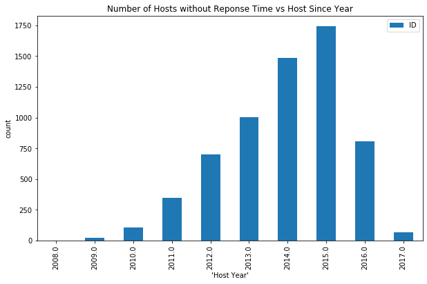

```python
check = df_host[out]
count_pid = check[['ID','Host Year']].groupby(['Host Year']).count().plot(kind='bar',figsize=(10,6), title='Number of Hosts without Reponse Time vs Host Since Year')
count_pid.set_xlabel("'Host Year'")
count_pid.set_ylabel("count")
```

#### 3.1.2 Treating null values & Converting Response Time in hours:

Since the number of Hosts which no response time recorded (null values = 6392) is more than the majority ) response time which is "within an hour". We assume the response time for null values also to be within an hour.

```python
#replace nan in Host Response Time = majority
Response_time = df_host['Host Response Time'].unique()
Response_time

# 'within an hour' = 1
# 'within a day' = 24
# 'within a few hours'=12
# 'a few days or more' = 72
```

```
array(['within an hour', nan, 'within a day', 'within a few hours',
       'a few days or more'], dtype=object)
```

```python
# create new column with response in hours

def resp (row):
#    if(row == 'within an hour'):
#        return 1
    if(row == 'within a day'):
        return 24
    if(row == 'within a few hours'):
        return 12
    if(row == 'a few days or more'):
        return 72
    return 1

df_host['Host Response Hours'] = df_host['Host Response Time'].apply(lambda row: resp(row))
```

```python
#new columns added are in the end : 'Host Year' and 'Host Response Hours'
df_host.head()
```

|  | ID | Host ID | Host Since | Host Response Time | Host Response Rate | Host Neighbourhood | Host Listings Count | Host Year | Host Response Hours |
| --- | --- | --- | --- | --- | --- | --- | --- | --- | --- |
| 0 | 17938814 | 55199493 | 2016-01-18 | within an hour | 100.0 | Long Island City | 1.0 | 2016.0 | 1 |
| 1 | 267561 | 1403098 | 2011-11-13 | NaN | NaN | Lower East Side | 1.0 | 2011.0 | 1 |
| 2 | 16301717 | 14256846 | 2014-04-14 | within a day | 86.0 | Lower East Side | 1.0 | 2014.0 | 24 |
| 3 | 834190 | 2369681 | 2012-05-14 | within an hour | 100.0 | Lower East Side | 1.0 | 2012.0 | 1 |
| 4 | 15582736 | 2167563 | 2012-04-18 | NaN | NaN | Lower East Side | 1.0 | 2012.0 | 1 |

### 3.2. Property Location Information : Removing NA

Regarding Location information , we are interested two features : 'Neighbourhood' and 'Neighbourhood Group'. This is because property prices vary across different areas of a City. There could be expnesive loacations and less expensive loacations. This impact property pricing as well as potential renting options depending on the budget.

```python
#information about location
df_loc = df_Airbnb_raw[loc_info]
print(df_loc.shape)
df_loc.head()
```

```
(19528, 9)
```

|  | ID | Transit | Access | Neighbourhood Cleansed | Neighbourhood Group Cleansed | Zipcode | Latitude | Longitude | Geolocation |
| --- | --- | --- | --- | --- | --- | --- | --- | --- | --- |
| 0 | 17938814 | NaN | NaN | Long Island City | Queens | 10021 | 40.746234 | -73.956953 | 40.7462341736, -73.9569527785 |
| 1 | 267561 | NaN | NaN | Lower East Side | Manhattan | 10002 | 40.720780 | -73.986421 | 40.7207796059, -73.9864214862 |
| 2 | 16301717 | NaN | NaN | Lower East Side | Manhattan | 10002 | 40.720939 | -73.983105 | 40.7209392264, -73.9831050977 |
| 3 | 834190 | 3-minute walk from 6 local subways : F, M, J,... | Guests have access to all they want - the res... | Lower East Side | Manhattan | 10002 | 40.719212 | -73.991159 | 40.7192118485, -73.9911591807 |
| 4 | 15582736 | NaN | Our house is your house! Use whatever you like... | Lower East Side | Manhattan | 10002 | 40.720132 | -73.983673 | 40.7201315734, -73.9836733593 |

```python
print(df_loc['Neighbourhood Cleansed'].nunique())
df_loc['Neighbourhood Cleansed'].unique()
```

```
98
```

```
array(['Long Island City', 'Lower East Side', 'Midtown', 'Kips Bay',
       'Little Italy', 'Murray Hill', 'Morningside Heights', 'NoHo',
       'Nolita', 'Roosevelt Island', 'SoHo', 'Stuyvesant Town',
       "Hell's Kitchen", 'Greenwich Village', 'Harlem', 'Inwood',
       'East Harlem', 'East Village', 'Financial District',
       'Flatiron District', 'Flatbush', 'Gramercy', 'Upper West Side',
       'Theater District', 'Tribeca', 'Two Bridges', 'Upper East Side',
       'Washington Heights', 'West Village', 'Williamsburg',
       'Ditmars Steinway', 'Astoria', 'Battery Park City',
       'Bedford-Stuyvesant', 'Prospect-Lefferts Gardens', 'Bushwick',
       'Chinatown', 'Chelsea', 'Civic Center', 'Concourse', 'Fairfax',
       'Jamaica Hills', 'Greenpoint', 'Crown Heights', 'East Flatbush',
       'Elmhurst', 'Sunset Park', 'Mariners Harbor', 'Sunnyside',
       'Ridgewood', 'Far Rockaway', 'Fort Greene', 'Fresh Meadows',
       'Gravesend', 'Kensington', 'Rockaway Beach', 'Marble Hill',
       'Port Morris', 'Kingsbridge', 'Midwood', 'Red Hook', 'Bensonhurst',
       'Concourse Village', 'Corona', 'Highbridge', 'Carroll Gardens',
       'Flushing', 'South Slope', 'Prospect Heights', 'Stapleton',
       'Fort Hamilton', 'Brooklyn Heights', 'Jamaica', 'Riverdale',
       'Park Slope', 'Rego Park', 'Morrisania', 'Throgs Neck',
       'Jackson Heights', 'Mott Haven', 'Cypress Hills', 'Arrochar',
       'Bay Ridge', 'Borough Park', 'Forest Hills', 'New Brighton',
       'Maspeth', 'Vinegar Hill', 'Brownsville', 'Bellerose', 'Longwood',
       'Clinton Hill', 'Boerum Hill', 'Morris Heights', 'Canarsie',
       'Ozone Park', 'Woodside', 'Bath Beach'], dtype=object)
```

```python
print(df_loc['Neighbourhood Group Cleansed'].nunique())
df_loc['Neighbourhood Group Cleansed'].unique()
```

```
5
```

```
array(['Queens', 'Manhattan', 'Brooklyn', 'Bronx', nan, 'Staten Island'],
      dtype=object)
```

```python
#checking null values in Neighbourhood Group

out = df_loc['Neighbourhood Group Cleansed'].isna()
print(df_loc['Neighbourhood Group Cleansed'].isna().sum())
```

```
1
```

```python
#only one observation with null value : This can be removed

df_loc[out].head()
```

|  | ID | Transit | Access | Neighbourhood Cleansed | Neighbourhood Group Cleansed | Zipcode | Latitude | Longitude | Geolocation |
| --- | --- | --- | --- | --- | --- | --- | --- | --- | --- |
| 709 | 1940118 | NaN | NaN | Fairfax | NaN | 10023 | 34.078371 | -118.353468 | 34.0783706158, -118.353468043 |

```python
#checking null values in Neighbourhood Cleansed : no null values present

out = df_loc['Neighbourhood Cleansed'].isna()
print(df_loc['Neighbourhood Cleansed'].isna().sum())
```

```
0
```

```python
#removing null values : observations count after removing null values

df_loc = df_loc[pd.notnull(df_loc['Neighbourhood Group Cleansed'])]
print(df_loc.shape)
```

```
(19527, 9)
```

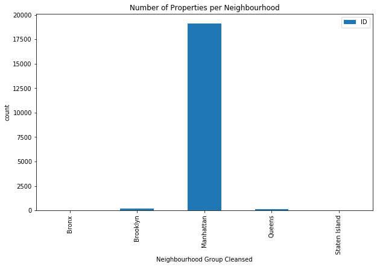

```python
count_pid = df_loc[['ID','Neighbourhood Group Cleansed']].groupby(['Neighbourhood Group Cleansed']).count().plot(kind='bar',figsize=(10,6), title='Number of Properties per Neighbourhood')
count_pid.set_xlabel('Neighbourhood Group Cleansed')
count_pid.set_ylabel("count")
```

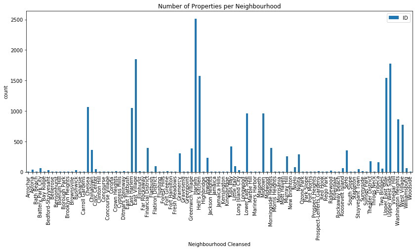

```python
cond = df_loc['Neighbourhood Group Cleansed'] == 'Manhattan'
check = df_loc[cond]
count_pid = df_loc[['ID','Neighbourhood Cleansed']].groupby(['Neighbourhood Cleansed']).count().plot(kind='bar',figsize=(14,6), title='Number of Properties per Neighbourhood')
count_pid.set_xlabel('Neighbourhood Cleansed')
count_pid.set_ylabel("count")
```

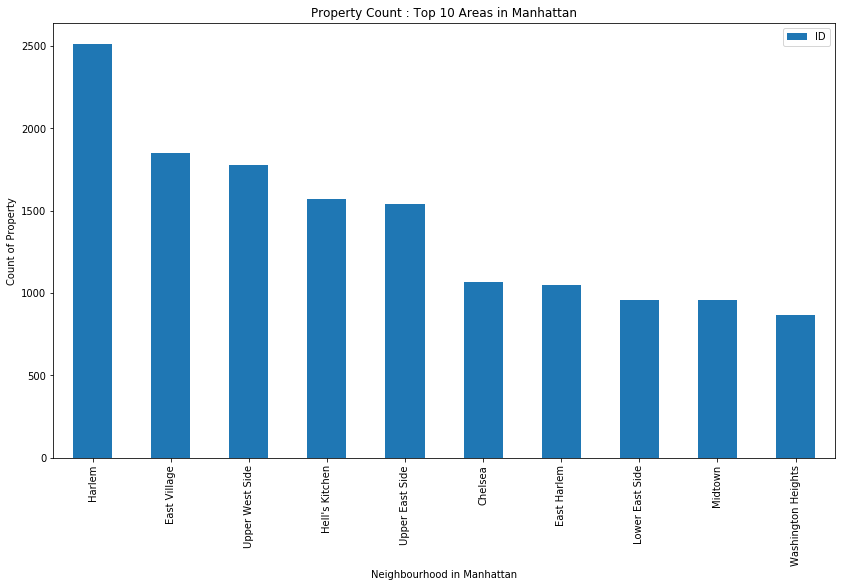

```python
cond = df_loc['Neighbourhood Group Cleansed'] == 'Manhattan'
check = df_loc[cond]
count_hood = check[['ID','Neighbourhood Cleansed']].groupby(['Neighbourhood Cleansed']).count()
count_hood['Neighbourhood Cleansed']=count_hood.index

count_hood.sort_values('ID',ascending=False).head(10).plot(kind='bar',figsize=(14,8), title='Trends : Top 10 Areas in Manhattan')
plt.xlabel("Neighbourhood in Manhattan")
plt.ylabel("Count of Property")
plt.title("Property Count : Top 10 Areas in Manhattan")
```

#### 3.2.1 Summary of Property Location Information :

1. The Neighbourhood group and Neighbourhood features contained only one null value. This observation is removed since it will not have a huge impact on our analysis.
2. Almost all the properties of Airbnb New York City are from Manhattan.
3. In Manhattan , below are the neighbourhoods with maximum number of properties.
   - Harlem
   - East Village
   - Upper West Side
   - Hell's Kitchen
   - Upper East Side

### 3.3. Property Information : Removing NA

This chunk of information countains all the details of each property listing like room type , capacity of occupants, Bed and Bath information, Amenitities such as TV, wifi, AC etc.

We extract the Amenities and convert it into dummy variables which can be later used for regression while estimating price of the property based on its features.

```python
#information about property
df_property = df_Airbnb_raw[property_info]
print(df_property.shape)
df_property.head()
```

```
(19528, 18)
```

|  | ID | Property Type | Room Type | Accommodates | Bathrooms | Bedrooms | Beds | Bed Type | Amenities | Square Feet | Price | Security Deposit | Cleaning Fee | Guests Included | Extra People | Minimum Nights | Maximum Nights | Cancellation Policy |
| --- | --- | --- | --- | --- | --- | --- | --- | --- | --- | --- | --- | --- | --- | --- | --- | --- | --- | --- |
| 0 | 17938814 | Apartment | Entire home/apt | 3 | 1.0 | 1.0 | 2.0 | Real Bed | TV,Cable TV,Wireless Internet,Kitchen,Smoking ... | NaN | 115.0 | NaN | NaN | 1 | 0 | 1 | 4 | flexible |
| 1 | 267561 | Apartment | Entire home/apt | 2 | 0.0 | 1.0 | 1.0 | Real Bed | TV,Internet,Wireless Internet,Air conditioning... | NaN | 290.0 | 299.0 | 45.0 | 2 | 200 | 1 | 30 | moderate |
| 2 | 16301717 | Apartment | Private room | 1 | 1.0 | 1.0 | 1.0 | Real Bed | Wireless Internet,Kitchen,Smoking allowed,Heat... | NaN | 60.0 | NaN | NaN | 1 | 0 | 6 | 1125 | flexible |
| 3 | 834190 | Loft | Private room | 5 | 1.0 | 1.0 | 3.0 | Real Bed | TV,Cable TV,Internet,Wireless Internet,Air con... | NaN | 99.0 | NaN | NaN | 2 | 50 | 1 | 29 | strict |
| 4 | 15582736 | Apartment | Private room | 1 | 1.0 | 1.0 | 1.0 | Real Bed | TV,Wireless Internet,Air conditioning,Kitchen,... | NaN | 110.0 | NaN | 49.0 | 1 | 0 | 5 | 1125 | strict |

```python
print(df_property['Property Type'].nunique())
df_property['Property Type'].unique()
```

```
22
```

```
array(['Apartment', 'Loft', 'Other', 'House', 'Condominium', 'Villa',
       'Townhouse', 'Serviced apartment', 'Timeshare', 'Bed & Breakfast',
       'Castle', 'Bungalow', 'Hostel', 'Guesthouse', 'Boutique hotel',
       'Lighthouse', 'Dorm', 'Vacation home', 'Cabin', 'Hut', 'Boat',
       'Guest suite'], dtype=object)
```

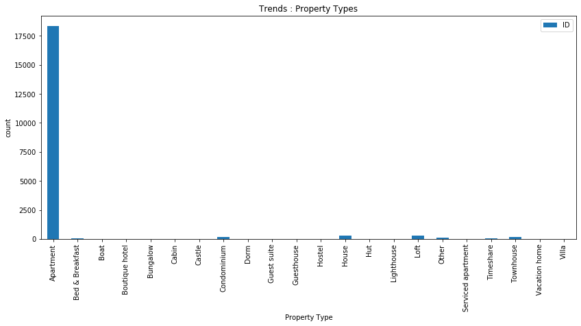

```python
# barplot
count_pid = df_property[['ID','Property Type']].groupby(['Property Type']).count().plot(kind='bar',figsize=(14,6), title='Trends : Property Types')
count_pid.set_xlabel('Property Type')
count_pid.set_ylabel("count")
```

```python
print(df_property['Room Type'].nunique())
df_property['Room Type'].unique()
```

```
3
```

```
array(['Entire home/apt', 'Private room', 'Shared room'], dtype=object)
```

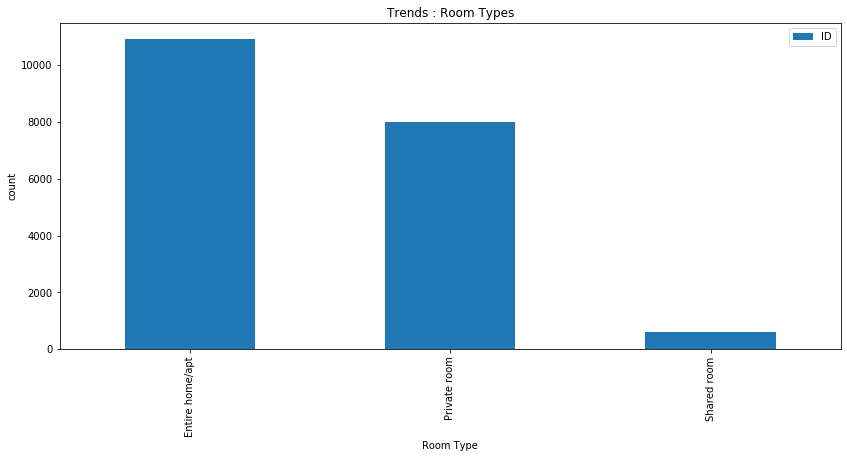

```python
count_pid = df_property[['ID','Room Type']].groupby(['Room Type']).count().plot(kind='bar',figsize=(14,6), title='Trends : Room Types')
count_pid.set_xlabel('Room Type')
count_pid.set_ylabel("count")
```

```
0
```

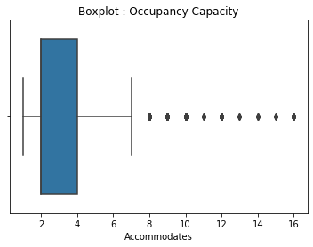

```python
# boxplot of the Accomodating capacity
print(df_property['Accommodates'].isna().sum()) #no nulls
ax=sns.boxplot(df_property['Accommodates'])
ax.set_title("Boxplot : Occupancy Capacity")
```

```python
#replacing null values with 0 were information regarding Bathrooms , Beds is blank

print(df_property['Bathrooms'].isna().sum())#74
df_property['Bathrooms'].fillna(0,inplace=True)

print(df_property['Beds'].isna().sum()) #45
df_property['Beds'].fillna(0,inplace=True)
```

```
74
45
```

```
5
['Real Bed' 'Pull-out Sofa' 'Airbed' 'Couch' 'Futon']
```

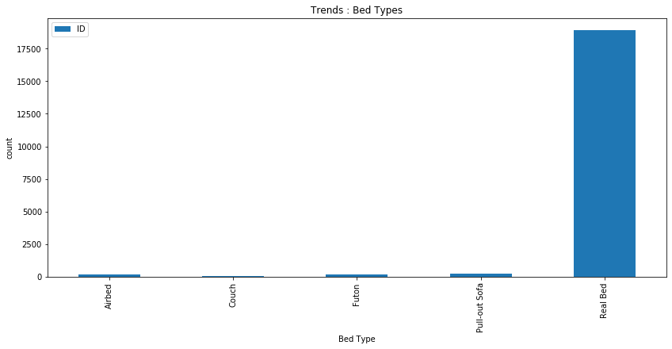

```python
print(df_property['Bed Type'].nunique())
print(df_property['Bed Type'].unique())

count_pid = df_property[['ID','Bed Type']].groupby(['Bed Type']).count().plot(kind='bar',figsize=(14,6), title='Trends : Bed Types')
count_pid.set_xlabel('Bed Type')
count_pid.set_ylabel("count")
```

```python
#checking null values for individual fields and treating NA

print(df_property['Guests Included'].isna().sum()) #no missing value
print(df_property['Extra People'].isna().sum()) #no missing value
print(df_property['Minimum Nights'].isna().sum()) #no missing value
print(df_property['Maximum Nights'].isna().sum()) #no missing value
print(df_property['Square Feet'].isna().sum()) #19275 missing values
#drop this field 'Square Feet' because 98% of observations donot have this information recorded
print(df_property['Cleaning Fee'].isna().sum()) #5843
df_property['Cleaning Fee'].fillna(0,inplace=True)
#replacing null values of Security Depost with 0
print(df_property['Security Deposit'].isna().sum()) #11378
df_property['Security Deposit'].fillna(0,inplace=True)
print(df_property['Price'].isna().sum()) #144
#These 144 missing Price values can be used as dataset for prediciton using regression models built

print(df_property.shape) #check if rows are reduced)
```

```
0
0
0
0
19275
5843
11378
144
(19528, 18)
```

```
0
['flexible' 'moderate' 'strict' 'super_strict_30']
```

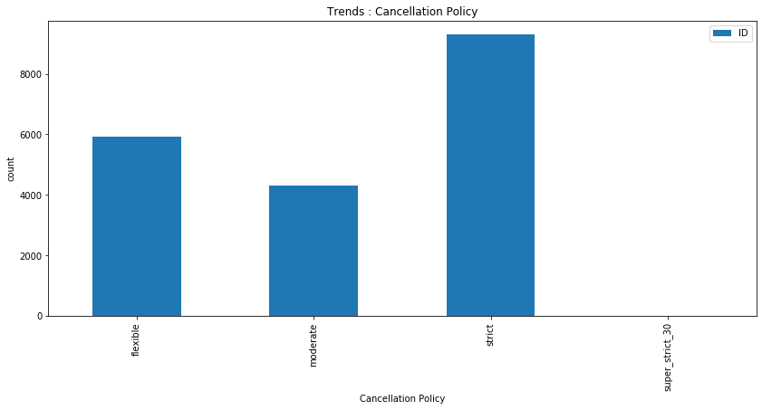

```python
print(df_property['Cancellation Policy'].isna().sum()) #no missing value
print(df_property['Cancellation Policy'].unique())

count_pid = df_property[['ID','Cancellation Policy']].groupby(['Cancellation Policy']).count().plot(kind='bar',figsize=(14,6), title='Trends : Cancellation Policy')
count_pid.set_xlabel('Cancellation Policy')
count_pid.set_ylabel("count")
```

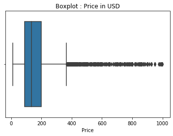

```python
# boxplot of the Accomodating capacity
ax=sns.boxplot(df_property['Price'])
ax.set_title("Boxplot : Price in USD")
```

```python
features = ['Price','Accommodates','Bathrooms','Bedrooms','Cleaning Fee','Minimum Nights','Maximum Nights']
df_property[features].describe()
```

|  | Price | Accommodates | Bathrooms | Bedrooms | Cleaning Fee | Minimum Nights | Maximum Nights |
| --- | --- | --- | --- | --- | --- | --- | --- |
| count | 19384.000000 | 19528.000000 | 19528.000000 | 19501.000000 | 19528.000000 | 19528.000000 | 1.952800e+04 |
| mean | 166.160803 | 2.798392 | 1.097629 | 1.093944 | 47.554844 | 4.200789 | 1.109504e+05 |
| std | 121.699317 | 1.737545 | 0.357389 | 0.683351 | 50.622343 | 17.171301 | 1.536743e+07 |
| min | 10.000000 | 1.000000 | 0.000000 | 0.000000 | 0.000000 | 1.000000 | 1.000000e+00 |
| 25% | 89.000000 | 2.000000 | 1.000000 | 1.000000 | 0.000000 | 1.000000 | 3.000000e+01 |
| 50% | 135.000000 | 2.000000 | 1.000000 | 1.000000 | 40.000000 | 2.000000 | 1.125000e+03 |
| 75% | 200.000000 | 4.000000 | 1.000000 | 1.000000 | 75.000000 | 3.000000 | 1.125000e+03 |
| max | 999.000000 | 16.000000 | 6.500000 | 6.000000 | 600.000000 | 1250.000000 | 2.147484e+09 |

```python
#data entry error
cond = df_property['Minimum Nights'] == max(df_property['Minimum Nights'])
df_property[cond]
```

|  | ID | Property Type | Room Type | Accommodates | Bathrooms | Bedrooms | Beds | Bed Type | Amenities | Square Feet | Price | Security Deposit | Cleaning Fee | Guests Included | Extra People | Minimum Nights | Maximum Nights | Cancellation Policy |
| --- | --- | --- | --- | --- | --- | --- | --- | --- | --- | --- | --- | --- | --- | --- | --- | --- | --- | --- |
| 13052 | 4204302 | Apartment | Entire home/apt | 3 | 1.0 | 1.0 | 1.0 | Real Bed | Internet,Wireless Internet,Air conditioning,Ki... | NaN | 180.0 | 0.0 | 60.0 | 1 | 0 | 1250 | 1250 | flexible |

```python
#data entry error
cond = df_property['Maximum Nights'] == max(df_property['Maximum Nights'])
df_property[cond]
```

|  | ID | Property Type | Room Type | Accommodates | Bathrooms | Bedrooms | Beds | Bed Type | Amenities | Square Feet | Price | Security Deposit | Cleaning Fee | Guests Included | Extra People | Minimum Nights | Maximum Nights | Cancellation Policy |
| --- | --- | --- | --- | --- | --- | --- | --- | --- | --- | --- | --- | --- | --- | --- | --- | --- | --- | --- |
| 7678 | 6357527 | Apartment | Entire home/apt | 1 | 1.0 | 0.0 | 1.0 | Real Bed | TV,Cable TV,Internet,Wireless Internet,Kitchen... | NaN | 130.0 | 0.0 | 35.0 | 1 | 0 | 2 | 2147483647 | flexible |

#### 3.3.2 Extracting Amenities and converting to Dummy variables

```python
print(df_property['Amenities'].nunique())
print(df_property['Amenities'].unique())
```

```
17213
['TV,Cable TV,Wireless Internet,Kitchen,Smoking allowed,Breakfast,Buzzer/wireless intercom,Heating,Family/kid friendly,Smoke detector,Essentials,Shampoo,Hangers,Hair dryer,Iron'
 'TV,Internet,Wireless Internet,Air conditioning,Kitchen,Elevator in building,Buzzer/wireless intercom,Heating,Washer,Dryer,Shampoo,Hangers,Hair dryer,Iron,Laptop friendly workspace,Self Check-In,Lockbox'
 'Wireless Internet,Kitchen,Smoking allowed,Heating,Essentials,Hangers,translation missing: en.hosting_amenity_49'
 ...
 'TV,Internet,Wireless Internet,Kitchen,Free parking on premises,Hot tub,Heating,Washer,Dryer,Smoke detector,Carbon monoxide detector,First aid kit,Fire extinguisher,Laptop friendly workspace'
 'TV,Internet,Wireless Internet,Air conditioning,Kitchen,Elevator in building,Heating,Washer,Dryer,Smoke detector,Carbon monoxide detector,Essentials,Hair dryer'
 'Wireless Internet,Air conditioning,Wheelchair accessible,Kitchen,Elevator in building,Heating,Washer,Dryer,Smoke detector,Carbon monoxide detector,Fire extinguisher,Essentials,Shampoo,24-hour check-in,Hangers,Hair dryer,Iron,Laptop friendly workspace,translation missing: en.hosting_amenity_49,tran…
```

```python
# For properties with no Amenities, we replace NA with 0

print(df_property['Amenities'].isna().sum())#138
df_property['Amenities'].fillna(0,inplace=True)
```

```
138
```

```python
# The Amenities column records unique values as comma separated lists. Below is an example

df_property['Amenities'][1]
```

```
'TV,Internet,Wireless Internet,Air conditioning,Kitchen,Elevator in building,Buzzer/wireless intercom,Heating,Washer,Dryer,Shampoo,Hangers,Hair dryer,Iron,Laptop friendly workspace,Self Check-In,Lockbox'
```

```python
# Dummy Variable conversion : We create a subset with ID and Amenities

df_amenities = df_property[['ID','Amenities']]
df_amenities.shape
```

```
(19528, 2)
```

```python
#check = df_amenities.set_index('Amenities').ID.str.split(',', expand=True).stack().reset_index('Amenities')
#check.head()

#Splitting the comma separated feature and exploding each cell creating duplicated IDs

df_amenities = df_amenities.set_index('ID').Amenities.str.split(',',expand=True).stack().reset_index("ID")
df_amenities.rename(columns={0:'Amenities'},inplace=True)
print(df_amenities.columns)
print(df_amenities.shape)
```

```
Index(['ID', 'Amenities'], dtype='object')
(300836, 2)
```

```python
df_amenities.head()
```

|  | ID | Amenities |
| --- | --- | --- |
| 0 | 17938814 | TV |
| 1 | 17938814 | Cable TV |
| 2 | 17938814 | Wireless Internet |
| 3 | 17938814 | Kitchen |
| 4 | 17938814 | Smoking allowed |

```python
#There are 94 unique Amenities listed
print(df_amenities['Amenities'].nunique())
df_amenities['Amenities'].value_counts().head()
```

```
94
```

```
Wireless Internet    18854
Kitchen              18380
Heating              18166
Air conditioning     16642
Essentials           16136
Name: Amenities, dtype: int64
```

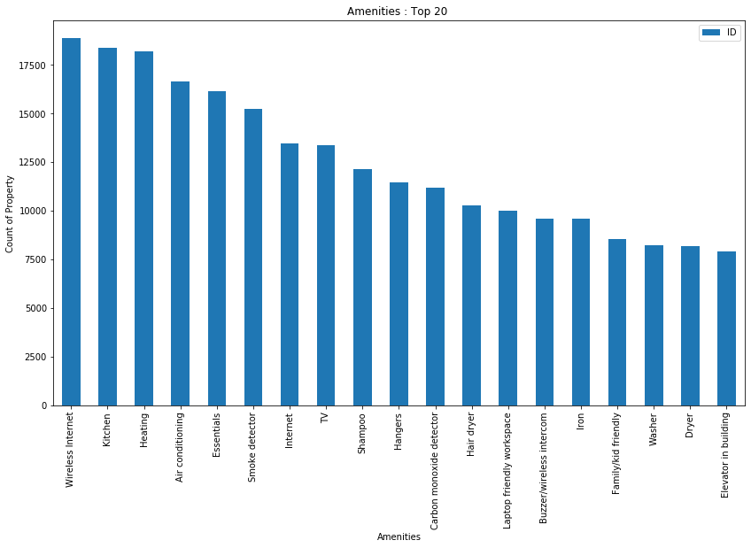

```python
count_hood = df_amenities[['ID','Amenities']].groupby(['Amenities']).count()
count_hood['Amenities']=count_hood.index

count_hood.sort_values('ID',ascending=False).head(19).plot(kind='bar',figsize=(14,8), title='Amenities Listed Majority Counts')
plt.xlabel("Amenities")
plt.ylabel("Count of Property")
plt.title("Amenities : Top 20 ")
```

```python
# Converting the Amentities column to dummy variables and summarizing the duplicated rows

dummy_amenities = pd.get_dummies(df_amenities['Amenities'])
dummy_amenities['ID'] = df_amenities['ID']
print(dummy_amenities.shape) #(300836, 95)
#dummy_amenities.head()#ducplicte IDs

#summarizing
check_amenities = dummy_amenities.groupby(dummy_amenities['ID']).sum()
print(check_amenities.shape) #(19390, 94)

#verfiy counts
dummy_amenities['ID'].nunique() #19390
```

```
(300836, 95)
(19390, 94)
```

```
19390
```

```python
#summarized
check_amenities.head()
```

| ID | 24-hour check-in | Accessible-height toilet | Air conditioning | BBQ grill | Baby bath | Baby monitor | Babysitter recommendations | Bathtub | Bed linens | Breakfast | ... | Washer / Dryer | Wheelchair accessible | Wide clearance to bed | Wide clearance to shower and toilet | Wide doorway | Wide hallway clearance | Window guards | Wireless Internet | translation missing: en.hosting_amenity_49 | translation missing: en.hosting_amenity_50 |
| --- | --- | --- | --- | --- | --- | --- | --- | --- | --- | --- | --- | --- | --- | --- | --- | --- | --- | --- | --- | --- | --- |
| 2515 | 0 | 0 | 1 | 0 | 0 | 0 | 0 | 0 | 0 | 0 | ... | 0 | 0 | 0 | 0 | 0 | 0 | 1 | 1 | 0 | 0 |
| 2595 | 1 | 0 | 1 | 0 | 0 | 0 | 0 | 0 | 0 | 0 | ... | 0 | 0 | 0 | 0 | 0 | 0 | 0 | 1 | 0 | 0 |
| 3647 | 0 | 0 | 1 | 0 | 0 | 0 | 0 | 0 | 0 | 0 | ... | 0 | 0 | 0 | 0 | 0 | 0 | 0 | 1 | 1 | 1 |
| 4611 | 0 | 0 | 1 | 0 | 0 | 0 | 0 | 0 | 0 | 0 | ... | 0 | 0 | 0 | 0 | 0 | 0 | 0 | 1 | 0 | 0 |
| 5099 | 0 | 0 | 0 | 0 | 0 | 0 | 0 | 0 | 0 | 0 | ... | 0 | 0 | 0 | 0 | 0 | 0 | 0 | 1 | 1 | 1 |

5 rows × 94 columns

#### 3.3.3 Summary of Property Information :

1. There are a total of 18 featuers describing a property listing.
2. Property Type : There are 22 different property types recorded on Airbnb NYC. A vast majority of which are Apartments.
3. Room Type : there are 3 differnt room types. Most of the listings rent out the entire space and vew few of them are shared.
4. 50% of the properties accomodate 2-4 occupants.
5. Most of the proerties have strick cancellation policies.
6. There are 94 unique Amenities listed for all properties. The basic ones common in all properties are Wifi, Kitchen, AC and Heating , Essentials etc.

### 3.4. Review Information : Removing NAs

The Review information contains property ratings based on people's renting experience.

Additionally the column 'Features' contains host and property location related feedback such has Super Host, accuracy of property location, Indentity verification. These featuers could contribute to the value of a property thereby influencing its price.

```python
#information about reviews
df_review = df_Airbnb_raw[review_info]
print(df_review.shape)
df_review.head()
```

```
(19528, 13)
```

|  | ID | Number of Reviews | First Review | Last Review | Review Scores Rating | Review Scores Accuracy | Review Scores Cleanliness | Review Scores Checkin | Review Scores Communication | Review Scores Location | Review Scores Value | Reviews per Month | Features |
| --- | --- | --- | --- | --- | --- | --- | --- | --- | --- | --- | --- | --- | --- |
| 0 | 17938814 | 3 | 2017-04-12 | 2017-04-24 | 100.0 | 9.0 | 9.0 | 9.0 | 9.0 | 10.0 | 10.0 | 3.00 | Host Has Profile Pic,Is Location Exact,Instant... |
| 1 | 267561 | 9 | 2011-12-13 | 2016-11-30 | 100.0 | 10.0 | 10.0 | 10.0 | 10.0 | 10.0 | 10.0 | 0.14 | Host Has Profile Pic,Is Location Exact |
| 2 | 16301717 | 1 | 2016-12-09 | 2017-04-19 | NaN | NaN | NaN | NaN | NaN | NaN | NaN | 0.20 | Host Has Profile Pic,Host Identity Verified,Is... |
| 3 | 834190 | 298 | 2017-02-23 | 2017-04-28 | 99.0 | 10.0 | 10.0 | 10.0 | 10.0 | 10.0 | 10.0 | 125.92 | Host Is Superhost,Host Has Profile Pic,Host Id... |
| 4 | 15582736 | 1 | 2016-11-15 | 2016-11-15 | 100.0 | 10.0 | 10.0 | 8.0 | 10.0 | 10.0 | 10.0 | 0.17 | Host Has Profile Pic,Host Identity Verified,Is... |

```python
#checking for null values and replacing them with 0.

print(df_review['Number of Reviews'].isna().sum())# no nulls
print(df_review['Review Scores Checkin'].isna().sum())# 4764
print(df_review['Review Scores Communication'].isna().sum())# 4743
print(df_review['Review Scores Location'].isna().sum())# 4769
print(df_review['Review Scores Value'].isna().sum())# 4765
print(df_review['Reviews per Month'].isna().sum())# 4397
print(df_review['Review Scores Rating'].isna().sum())# 4720
print(df_review['Review Scores Accuracy'].isna().sum())# 4720
print(df_review['Review Scores Cleanliness'].isna().sum())# 4744
print(df_review['Features'].isna().sum())#27
print(df_review['First Review'].isna().sum())#4397
print(df_review['Last Review'].isna().sum())#4341

df_review['Review Scores Accuracy'].fillna(0,inplace=True)
df_review['Review Scores Checkin'].fillna(0,inplace=True)# 4764
df_review['Review Scores Communication'].fillna(0,inplace=True)# 4743
df_review['Review Scores Location'].fillna(0,inplace=True)# 4769
df_review['Review Scores Value'].fillna(0,inplace=True)# 4765
df_review['Reviews per Month'].fillna(0,inplace=True)# 4397
df_review['Review Scores Rating'].fillna(0,inplace=True)# 4720
df_review['Review Scores Cleanliness'].fillna(0,inplace=True)# 4744
df_review['Features'].fillna(0,inplace=True)#27

#df_review[['Review Scores Checkin','Review Scores Communication','Review Scores Location','Review Scores Value','Reviews per Month','Review Scores Rating','Review Scores Accuracy','Review Scores Cleanliness']].fillna(0,inplace=True)
```

```
0
4764
4743
4769
4765
4397
4720
4760
4744
27
4397
4341
```

Note : No ratings recorded could indicate the property to be new or not being rented or not been reviewed. Therefore, we can set them to 0 as an initialization.

#### 3.4.1 Extracting Review Features and converting to Dummy variables

```python
#create a subset with Proerty ID and Features column
df_features = df_review[['ID','Features']]
print("Dimensions of subsetted data")
print(df_features.shape)

#split the comma separated values for each property and explode to multiple rows
df_features = df_features.set_index('ID').Features.str.split(',',expand=True).stack().reset_index("ID")
#print(df_features.head())
print("\nDimensions of data by extracting comma separated features")
print(df_features.shape)
#print("Dimensions of data by extracting comma separated features")
#print(df_features.columns)


df_features.rename(columns={0:'Features'},inplace=True)
print("\nDuplicated Property ID with individual feature listed")
print(df_features.head())

#count unique values
df_features['Features'].nunique()
df_features['Features'].value_counts()

#create dummy Variables
dummy_features = pd.get_dummies(df_features['Features'])
dummy_features['ID'] = df_features['ID']
print("\nDimensions of data with dummy features")
print(dummy_features.shape)

#preview data
#print("\nSummarized Property ID with individual features as dummy variables")
#dummy_features.head()
```

```
Dimensions of subsetted data
(19528, 2)

Dimensions of data by extracting comma separated features
(54801, 2)

Duplicated Property ID with individual feature listed
         ID              Features
0  17938814  Host Has Profile Pic
1  17938814     Is Location Exact
2  17938814      Instant Bookable
0    267561  Host Has Profile Pic
1    267561     Is Location Exact

Dimensions of data with dummy features
(54801, 8)
```

```python
check_features = dummy_features.groupby(dummy_features['ID']).sum()

print("\nSummarized Property ID with individual features as dummy variables")
print(check_features.shape)
#verify count
print(dummy_features['ID'].nunique())
check_features.head()
```

```
Summarized Property ID with individual features as dummy variables
(19501, 7)
19501
```

| ID | Host Has Profile Pic | Host Identity Verified | Host Is Superhost | Instant Bookable | Is Location Exact | Require Guest Phone Verification | Require Guest Profile Picture |
| --- | --- | --- | --- | --- | --- | --- | --- |
| 2515 | 1 | 1 | 0 | 0 | 1 | 0 | 0 |
| 2595 | 1 | 1 | 0 | 0 | 0 | 1 | 1 |
| 3647 | 1 | 1 | 0 | 0 | 1 | 1 | 1 |
| 4611 | 1 | 0 | 0 | 1 | 1 | 0 | 0 |
| 5099 | 1 | 1 | 0 | 0 | 0 | 1 | 1 |

### 3.5. Price Information :

Here, we just extract the price information because Weekly Price and Monthly Price are not required for estimating the price of the property with respect to the property features.

```python
#information about price
df_price = df_Airbnb_raw[price_info]
print(df_price.shape)
df_price.head()
```

```
(19528, 4)
```

|  | ID | Price | Weekly Price | Monthly Price |
| --- | --- | --- | --- | --- |
| 0 | 17938814 | 115.0 | NaN | NaN |
| 1 | 267561 | 290.0 | NaN | 5900.0 |
| 2 | 16301717 | 60.0 | NaN | NaN |
| 3 | 834190 | 99.0 | NaN | NaN |
| 4 | 15582736 | 110.0 | NaN | NaN |

## 4. Merging Chunks by Property ID

```python
# Each set of data is of different dimension due to the removal of null values and creation of dummy variables.
print(df_host.shape)
print(df_loc.shape)
print(df_property.shape)
print(check_amenities.shape)
print(df_review.shape)
print(check_features.shape)
```

```
(19419, 9)
(19527, 9)
(19528, 18)
(19390, 94)
(19528, 13)
(19501, 7)
```

### 4.1 Each set of data is exported to CSV

```python
#df_host.to_csv("Host_Info", sep=',', encoding='utf-8')
path=r'F:\\Rutgers Coursework - Sem 1\\Algorithmic Machine Learning\\Project\\Cleaned Files'
df_host[["ID","Host Year","Host Response Hours"]].to_csv(path+'\\Host_Info.csv',index=False)
```

```python
#df_host.to_csv("Host_Info", sep=',', encoding='utf-8')
path=r'F:\\Rutgers Coursework - Sem 1\\Algorithmic Machine Learning\\Project\\Cleaned Files'
df_loc[["ID","Neighbourhood Cleansed","Neighbourhood Group Cleansed"]].to_csv(path+'\\Location_Info.csv',index=False)
```

```python
#df_host.to_csv("Host_Info", sep=',', encoding='utf-8')
path=r'F:\\Rutgers Coursework - Sem 1\\Algorithmic Machine Learning\\Project\\Cleaned Files'
df_property[df_property.columns.difference(["Amenities","Square Feet"])].to_csv(path+'\\Property_Info.csv',index=False)
```

```python
#df_host.to_csv("Host_Info", sep=',', encoding='utf-8')
path=r'F:\\Rutgers Coursework - Sem 1\\Algorithmic Machine Learning\\Project\\Cleaned Files'
check_amenities.to_csv(path+'\\Amenities_Info.csv',index=False)
```

```python
#df_host.to_csv("Host_Info", sep=',', encoding='utf-8')
path=r'F:\\Rutgers Coursework - Sem 1\\Algorithmic Machine Learning\\Project\\Cleaned Files'
df_review[df_review.columns.difference(["First Review","Last Review","Features"])].to_csv(path+'\\Review_Info.csv',index=False)
```

```python
#df_host.to_csv("Host_Info", sep=',', encoding='utf-8')
path=r'F:\\Rutgers Coursework - Sem 1\\Algorithmic Machine Learning\\Project\\Cleaned Files'
check_features.to_csv(path+'\\Features_Info.csv',index=False)
```

### 4.2 Merge with Inner Join on Property ID

```python
# inner join
host = df_host[["ID","Host Year","Host Response Hours"]]
loc = df_loc[["ID","Neighbourhood Cleansed","Neighbourhood Group Cleansed"]]
prop = df_property[df_property.columns.difference(["Amenities","Square Feet"])]
review = df_review[df_review.columns.difference(["First Review","Last Review","Features"])]
#df_merge = pd.merge(host,loc,prop, review, check_amenities,check_features, on="ID",how="inner")
```

```python
from functools import reduce
df_merge = reduce(lambda x,y:pd.merge(x,y, on="ID",how="inner"), [host,loc,prop, review, check_amenities,check_features] )
```

```python
df_merge.shape
```

```
(19273, 130)
```

```python
df_merge.head()
```

|  | ID | Host Year | Host Response Hours | Neighbourhood Cleansed | Neighbourhood Group Cleansed | Accommodates | Bathrooms | Bed Type | Bedrooms | Beds | ... | Wireless Internet | translation missing: en.hosting_amenity_49 | translation missing: en.hosting_amenity_50 | Host Has Profile Pic | Host Identity Verified | Host Is Superhost | Instant Bookable | Is Location Exact | Require Guest Phone Verification | Require Guest Profile Picture |
| --- | --- | --- | --- | --- | --- | --- | --- | --- | --- | --- | --- | --- | --- | --- | --- | --- | --- | --- | --- | --- | --- |
| 0 | 17938814 | 2016.0 | 1 | Long Island City | Queens | 3 | 1.0 | Real Bed | 1.0 | 2.0 | ... | 1 | 0 | 0 | 1 | 0 | 0 | 1 | 1 | 0 | 0 |
| 1 | 267561 | 2011.0 | 1 | Lower East Side | Manhattan | 2 | 0.0 | Real Bed | 1.0 | 1.0 | ... | 1 | 0 | 0 | 1 | 0 | 0 | 0 | 1 | 0 | 0 |
| 2 | 16301717 | 2014.0 | 24 | Lower East Side | Manhattan | 1 | 1.0 | Real Bed | 1.0 | 1.0 | ... | 1 | 1 | 0 | 1 | 1 | 0 | 0 | 1 | 0 | 0 |
| 3 | 834190 | 2012.0 | 1 | Lower East Side | Manhattan | 5 | 1.0 | Real Bed | 1.0 | 3.0 | ... | 1 | 0 | 0 | 1 | 1 | 1 | 1 | 1 | 0 | 0 |
| 4 | 15582736 | 2012.0 | 1 | Lower East Side | Manhattan | 1 | 1.0 | Real Bed | 1.0 | 1.0 | ... | 1 | 1 | 1 | 1 | 1 | 0 | 1 | 1 | 0 | 0 |

5 rows × 130 columns

```python
# missing price observations can be used to apply the Prediction Models
df_merge['Price'].isna().sum()
```

```
131
```

### 4.3 Export Merged data to CSV

```python
#extracting Merged data to csv

path=r'F:\\Rutgers Coursework - Sem 1\\Algorithmic Machine Learning\\Project\\Cleaned Files'
df_merge.to_csv(path+'\\Merged_Airbnb.csv',index=False)
```

```python
# For EDA purpose, remove price = 0 and null
df_merge_old = df_merge
df_merge=df_merge[pd.notnull(df_merge['Price'])]
cond = df_merge['Price']==0
df_merge[cond].shape
```

```
(0, 130)
```

## 5. Exploratory Data Analysis

This analysis is to estimate the price of a property. In the graphs below, we look at variations in Price with respect to Property Type, Location and Ratings.

### 5.1 Distribution of Price

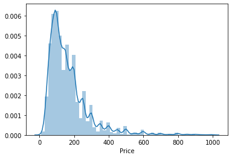

```python
#remove outliers

df_plot = df_merge[pd.notnull(df_merge['Price'])]
sns.distplot(df_plot['Price'])
```

```python
df_merge['Price'].describe()
```

```
count    19142.000000
mean       166.267736
std        121.693285
min         10.000000
25%         89.000000
50%        135.000000
75%        200.000000
max        999.000000
Name: Price, dtype: float64
```

### 5.2 Price vs. Neighbourhood

```python
df_subset = (df_merge[['Neighbourhood Group Cleansed','Price']].groupby(['Neighbourhood Group Cleansed']).mean())
df_subset
```

| Neighbourhood Group Cleansed | Price |
| --- | --- |
| Bronx | 71.133333 |
| Brooklyn | 126.966981 |
| Manhattan | 167.371371 |
| Queens | 89.721429 |
| Staten Island | 106.000000 |

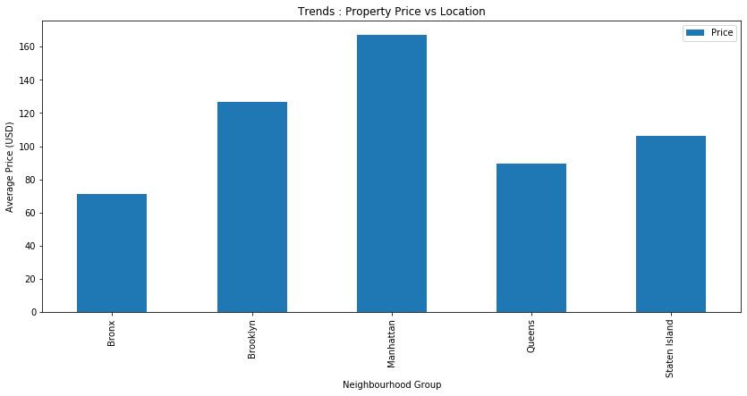

```python
count_pid = df_subset.plot(kind='bar',figsize=(14,6), title='Trends : Property Price vs Location')
count_pid.set_xlabel('Neighbourhood Group')
count_pid.set_ylabel("Average Price (USD)")
```

### 5.3 Price vs Neighbourhood vs Property Type

```python
df_subset = df_merge[['Neighbourhood Group Cleansed','Property Type','Price']].groupby(['Neighbourhood Group Cleansed','Property Type']).mean()
df_subset
```

| Neighbourhood Group Cleansed | Property Type | Price |
| --- | --- | --- |
| Bronx | Apartment | 76.000000 |
|  | House | 57.750000 |
| Brooklyn | Apartment | 122.248555 |
|  | Condominium | 116.250000 |
|  | House | 138.217391 |
|  | Loft | 155.600000 |
|  | Townhouse | 284.000000 |
| Manhattan | Apartment | 162.666065 |
|  | Bed & Breakfast | 165.196429 |
|  | Boat | 600.000000 |
|  | Boutique hotel | 205.727273 |
|  | Bungalow | 185.000000 |
|  | Cabin | 250.000000 |
|  | Castle | 175.000000 |
|  | Condominium | 286.071429 |
|  | Dorm | 66.666667 |
|  | Guest suite | 332.000000 |
|  | Guesthouse | 85.153846 |
|  | Hostel | 76.416667 |
|  | House | 232.483412 |
|  | Hut | 50.000000 |
|  | Lighthouse | 221.000000 |
|  | Loft | 288.746888 |
|  | Other | 178.868687 |
|  | Serviced apartment | 420.800000 |
|  | Timeshare | 343.945946 |
|  | Townhouse | 228.994048 |
|  | Vacation home | 529.000000 |
|  | Villa | 264.000000 |
| Queens | Apartment | 94.812500 |
|  | Condominium | 200.000000 |
|  | House | 73.025000 |
|  | Loft | 119.500000 |
|  | Townhouse | 99.000000 |
| Staten Island | Apartment | 87.000000 |
|  | House | 125.000000 |

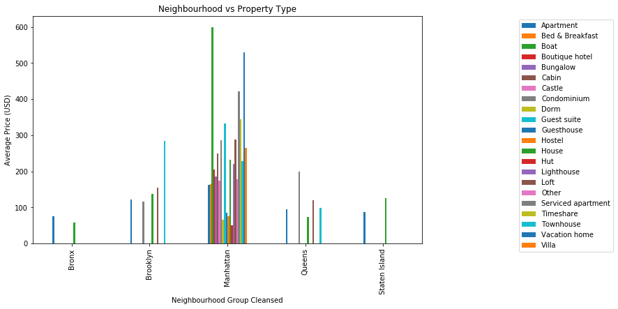

```python
df_sidestack = df_merge.groupby(['Neighbourhood Group Cleansed','Property Type'])['Price'].mean()

df_sidestack.unstack().plot.bar(figsize=(10,6))
plt.legend(loc='upper right', bbox_to_anchor=(1.5,1))
plt.title("Neighbourhood vs Property Type")
plt.ylabel("Average Price (USD)")
```

```python
#Decreasing order of Average Price in Mahnattan based on property type
cond = df_merge['Neighbourhood Group Cleansed'] == 'Manhattan'
subset = df_merge[cond]
df_subset = subset[['Property Type','Price']].groupby(['Property Type']).mean()
df_subset.sort_values('Price',ascending=False).head()
```

| Property Type | Price |
| --- | --- |
| Boat | 600.000000 |
| Vacation home | 529.000000 |
| Serviced apartment | 420.800000 |
| Timeshare | 343.945946 |
| Guest suite | 332.000000 |

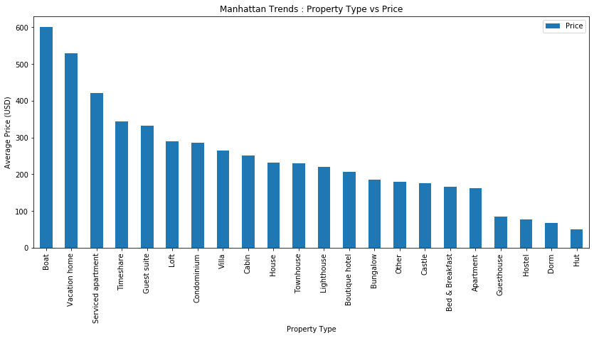

```python
count_pid = df_subset.sort_values('Price',ascending=False).plot(kind='bar',figsize=(14,6), title='Manhattan Trends : Property Type vs Price')
count_pid.set_xlabel('Property Type')
count_pid.set_ylabel("Average Price (USD)")
```

### 5.4 Price vs Neighbourhood vs Room Type

```python
df_subset = df_merge[['Neighbourhood Group Cleansed','Room Type','Price']].groupby(['Neighbourhood Group Cleansed','Room Type']).mean()
df_subset
```

| Neighbourhood Group Cleansed | Room Type | Price |
| --- | --- | --- |
| Bronx | Entire home/apt | 128.000000 |
|  | Private room | 56.916667 |
| Brooklyn | Entire home/apt | 195.100000 |
|  | Private room | 77.686441 |
|  | Shared room | 47.750000 |
| Manhattan | Entire home/apt | 220.949148 |
|  | Private room | 99.811429 |
|  | Shared room | 80.225177 |
| Queens | Entire home/apt | 143.224490 |
|  | Private room | 61.488372 |
|  | Shared room | 51.000000 |
| Staten Island | Entire home/apt | 74.666667 |
|  | Private room | 200.000000 |

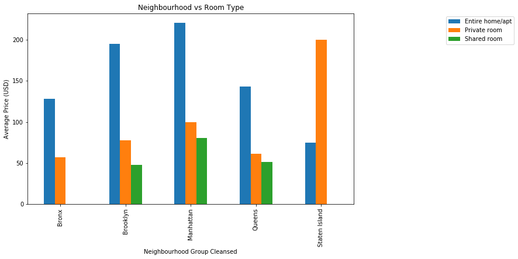

```python
df_sidestack = df_merge.groupby(['Neighbourhood Group Cleansed','Room Type'])['Price'].mean()

df_sidestack.unstack().plot.bar(figsize=(10,6))
plt.legend(loc='upper right', bbox_to_anchor=(1.5,1))
plt.title("Neighbourhood vs Room Type")
plt.ylabel("Average Price (USD)")
```

Note : The higher price for private room at staten island is listed by a single property

```python
#staten island - The higher price for private room at staten island is listed by a single property

cond = df_merge['Neighbourhood Group Cleansed']=='Staten Island'
cond_type = df_merge['Room Type'] == 'Private room'

#print(df_merge[cond & cond_type])

df_merge[cond & cond_type].melt(id_vars=["ID"],
        var_name="Fields",
        value_name="Value").head()
```

|  | ID | Fields | Value |
| --- | --- | --- | --- |
| 0 | 14654676 | Host Year | 2014 |
| 1 | 14654676 | Host Response Hours | 1 |
| 2 | 14654676 | Neighbourhood Cleansed | Mariners Harbor |
| 3 | 14654676 | Neighbourhood Group Cleansed | Staten Island |
| 4 | 14654676 | Accommodates | 2 |

### 5.5 Neighbourhood vs Review

```python
df_review.columns
```

```
Index(['ID', 'Number of Reviews', 'First Review', 'Last Review',
       'Review Scores Rating', 'Review Scores Accuracy',
       'Review Scores Cleanliness', 'Review Scores Checkin',
       'Review Scores Communication', 'Review Scores Location',
       'Review Scores Value', 'Reviews per Month', 'Features'],
      dtype='object')
```

```python
features = ['Neighbourhood Group Cleansed','Room Type','Number of Reviews','Review Scores Rating','Review Scores Accuracy','Review Scores Cleanliness','Review Scores Checkin','Review Scores Communication','Review Scores Location','Review Scores Value']
subset=df_merge[features]
df_merge[features].describe()
```

|  | Number of Reviews | Review Scores Rating | Review Scores Accuracy | Review Scores Cleanliness | Review Scores Checkin | Review Scores Communication | Review Scores Location | Review Scores Value |
| --- | --- | --- | --- | --- | --- | --- | --- | --- |
| count | 19142.000000 | 19142.000000 | 19142.000000 | 19142.000000 | 19142.000000 | 19142.000000 | 19142.000000 | 19142.000000 |
| mean | 16.972835 | 70.832881 | 7.231428 | 6.975551 | 7.377808 | 7.414481 | 7.284558 | 7.082437 |
| std | 30.819924 | 40.106143 | 4.114301 | 4.017597 | 4.175701 | 4.180677 | 4.127905 | 4.039329 |
| min | 0.000000 | 0.000000 | 0.000000 | 0.000000 | 0.000000 | 0.000000 | 0.000000 | 0.000000 |
| 25% | 1.000000 | 67.000000 | 7.000000 | 6.000000 | 8.000000 | 8.000000 | 7.000000 | 6.000000 |
| 50% | 5.000000 | 92.000000 | 9.000000 | 9.000000 | 10.000000 | 10.000000 | 10.000000 | 9.000000 |
| 75% | 19.000000 | 98.000000 | 10.000000 | 10.000000 | 10.000000 | 10.000000 | 10.000000 | 10.000000 |
| max | 432.000000 | 100.000000 | 10.000000 | 10.000000 | 10.000000 | 10.000000 | 10.000000 | 10.000000 |

```python
df_subset = subset.groupby(['Neighbourhood Group Cleansed','Room Type']).mean().reset_index()
df_subset.head()
```

|  | Neighbourhood Group Cleansed | Room Type | Number of Reviews | Review Scores Rating | Review Scores Accuracy | Review Scores Cleanliness | Review Scores Checkin | Review Scores Communication | Review Scores Location | Review Scores Value |
| --- | --- | --- | --- | --- | --- | --- | --- | --- | --- | --- |
| 0 | Bronx | Entire home/apt | 1.333333 | 33.333333 | 3.333333 | 3.333333 | 3.333333 | 3.333333 | 3.333333 | 3.333333 |
| 1 | Bronx | Private room | 13.500000 | 70.083333 | 7.166667 | 7.000000 | 7.250000 | 7.166667 | 6.750000 | 7.000000 |
| 2 | Brooklyn | Entire home/apt | 15.377778 | 73.577778 | 7.377778 | 7.322222 | 7.622222 | 7.711111 | 7.400000 | 7.411111 |
| 3 | Brooklyn | Private room | 10.237288 | 59.169492 | 6.042373 | 5.745763 | 6.177966 | 6.101695 | 5.881356 | 5.932203 |
| 4 | Brooklyn | Shared room | 9.250000 | 47.250000 | 4.750000 | 4.750000 | 4.750000 | 4.750000 | 4.750000 | 4.500000 |

```python
# melt function is used to covert columns to rows

df_plot = df_subset.melt(id_vars=['Neighbourhood Group Cleansed','Room Type'],
        var_name="score_param",
        value_name="avg_value").groupby(['Neighbourhood Group Cleansed','Room Type','score_param']).mean().reset_index()

df_plot.head()
```

|  | Neighbourhood Group Cleansed | Room Type | score_param | avg_value |
| --- | --- | --- | --- | --- |
| 0 | Bronx | Entire home/apt | Number of Reviews | 1.333333 |
| 1 | Bronx | Entire home/apt | Review Scores Accuracy | 3.333333 |
| 2 | Bronx | Entire home/apt | Review Scores Checkin | 3.333333 |
| 3 | Bronx | Entire home/apt | Review Scores Cleanliness | 3.333333 |
| 4 | Bronx | Entire home/apt | Review Scores Communication | 3.333333 |

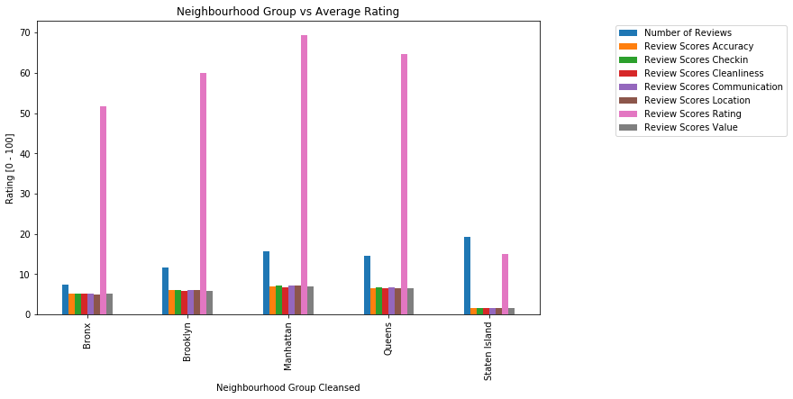

```python
df_sidestack = df_plot.groupby(['Neighbourhood Group Cleansed','score_param'])['avg_value'].mean()

df_sidestack.unstack().plot.bar(figsize=(10,6))
plt.legend(loc='upper right', bbox_to_anchor=(1.5,1))
plt.title("Neighbourhood Group vs Average Rating")
plt.ylabel("Rating [0 - 100]")
```

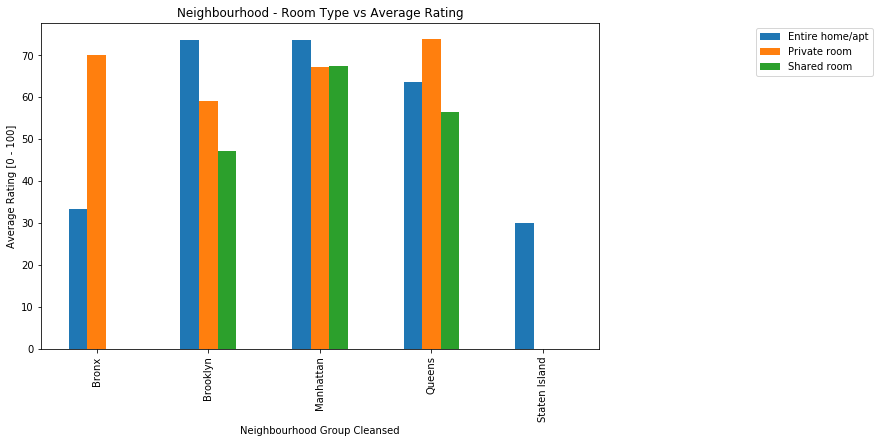

```python
df_sidestack = subset.groupby(['Neighbourhood Group Cleansed','Room Type'])['Review Scores Rating'].mean()

df_sidestack.unstack().plot.bar(figsize=(10,6))
plt.legend(loc='upper right', bbox_to_anchor=(1.5,1))
plt.title("Neighbourhood - Room Type vs Average Rating")
plt.ylabel("Average Rating [0 - 100]")
```

### 5.6 Price vs Reviews

```python
df_merge['Review Scores Rating'].unique()
```

```
array([100.,   0.,  99.,  80.,  87.,  88.,  98.,  90.,  94.,  73.,  91.,
        96.,  89.,  83.,  92.,  84.,  93.,  95.,  97.,  85.,  78.,  82.,
        86.,  60.,  50.,  62.,  76.,  68.,  65.,  40.,  75.,  70.,  81.,
        79.,  20.,  53.,  66.,  72.,  64.,  71.,  77.,  63.,  67.,  74.,
        69.,  27.,  47.,  30.])
```

```
                         Price  Review Scores Rating
Price                 1.000000             -0.016277
Review Scores Rating -0.016277              1.000000
```

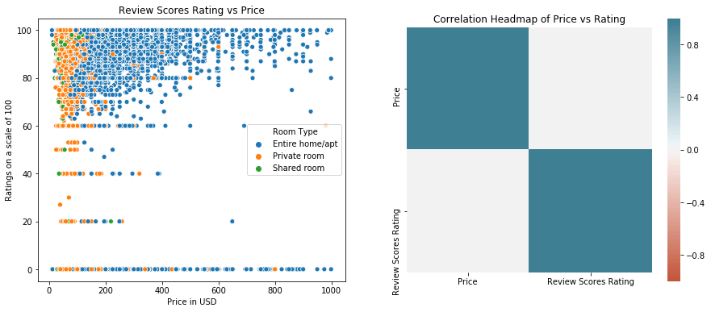

```python
#Correlations and Subplots for Price vs Review

#subplot settings
fig, axes = plt.subplots(ncols=2,figsize=(15,6))

#fig.tight_layout()
fig.subplots_adjust(hspace=2)

#correlation matrix


df1=df_merge[["Price","Review Scores Rating"]]
corr_matrix = df1.corr()


#scatterplot

sns.scatterplot(y="Review Scores Rating", x="Price",hue="Room Type", data= df_merge, ax=axes[0])
axes[0].set_title('Review Scores Rating vs Price')
axes[0].set_xlabel('Price in USD')
axes[0].set_ylabel('Ratings on a scale of 100')

#correlleogram

sns.heatmap(corr_matrix, vmin=-1, vmax=1, center=0,
    cmap=sns.diverging_palette(20, 220, n=200),
    square=True, ax=axes[1])
axes[1].set_title('Correlation Headmap of Price vs Rating')

print(corr_matrix)
```

```python
#,'Neighbourhood Group Cleansed','Room Type'
features = ['ID','Price','Number of Reviews','Review Scores Rating','Review Scores Accuracy','Review Scores Cleanliness','Review Scores Checkin','Review Scores Communication','Review Scores Location','Review Scores Value']
subset=df_merge[features]
df_merge[features].describe()
df_merge[features].head()
```

|  | ID | Price | Number of Reviews | Review Scores Rating | Review Scores Accuracy | Review Scores Cleanliness | Review Scores Checkin | Review Scores Communication | Review Scores Location | Review Scores Value |
| --- | --- | --- | --- | --- | --- | --- | --- | --- | --- | --- |
| 0 | 17938814 | 115.0 | 3 | 100.0 | 9.0 | 9.0 | 9.0 | 9.0 | 10.0 | 10.0 |
| 1 | 267561 | 290.0 | 9 | 100.0 | 10.0 | 10.0 | 10.0 | 10.0 | 10.0 | 10.0 |
| 2 | 16301717 | 60.0 | 1 | 0.0 | 0.0 | 0.0 | 0.0 | 0.0 | 0.0 | 0.0 |
| 3 | 834190 | 99.0 | 298 | 99.0 | 10.0 | 10.0 | 10.0 | 10.0 | 10.0 | 10.0 |
| 4 | 15582736 | 110.0 | 1 | 100.0 | 10.0 | 10.0 | 8.0 | 10.0 | 10.0 | 10.0 |

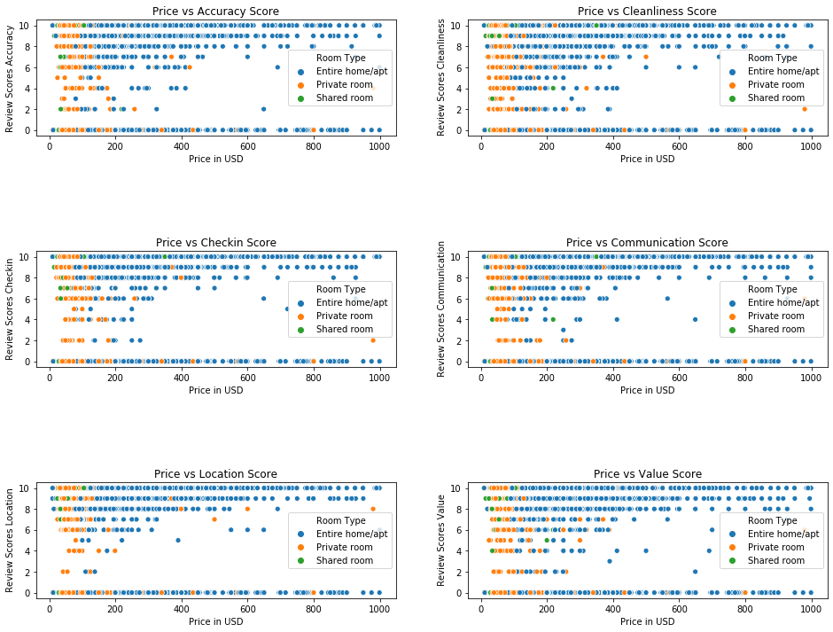

```python
# Scatter Plot of prices vs each rating

features = ['ID','Price','Review Scores Accuracy','Review Scores Cleanliness','Review Scores Checkin','Review Scores Communication','Review Scores Location','Review Scores Value']

#subplot settings
fig, axes = plt.subplots(nrows=3,ncols=2,figsize=(16,12))

fig.subplots_adjust(hspace=1)

sns.scatterplot(x="Price", y="Review Scores Accuracy", hue="Room Type", data= df_merge, ax=axes[0][0])
axes[0][0].set_title('Price vs Accuracy Score')
axes[0][0].set_xlabel(' Price in USD ')
axes[0][0].set_ylabel('Review Scores Accuracy')

sns.scatterplot(x="Price", y="Review Scores Cleanliness", hue="Room Type",data= df_merge, ax=axes[0][1])
axes[0][1].set_title('Price vs Cleanliness Score')
axes[0][1].set_xlabel('Price in USD')
axes[0][1].set_ylabel(' Review Scores Cleanliness')

sns.scatterplot(x="Price", y="Review Scores Checkin",hue="Room Type", data= df_merge, ax=axes[1][0])
axes[1][0].set_title('Price vs Checkin Score')
axes[1][0].set_xlabel('Price in USD')
axes[1][0].set_ylabel(' Review Scores Checkin')

sns.scatterplot(x="Price", y="Review Scores Communication",hue="Room Type", data= df_merge, ax=axes[1][1])
axes[1][1].set_title('Price vs Communication Score')
axes[1][1].set_xlabel('Price in USD')
axes[1][1].set_ylabel(' Review Scores Communication')

sns.scatterplot(x="Price", y="Review Scores Location",hue="Room Type", data= df_merge, ax=axes[2][0])
axes[2][0].set_title('Price vs Location Score')
axes[2][0].set_xlabel('Price in USD')
axes[2][0].set_ylabel(' Review Scores Location')

sns.scatterplot(x="Price", y="Review Scores Value",hue="Room Type", data= df_merge, ax=axes[2][1])
axes[2][1].set_title('Price vs Value Score')
axes[2][1].set_xlabel('Price in USD')
axes[2][1].set_ylabel(' Review Scores Value')
```

### 5.7 Price vs Amenities

```python
# price vs Amenities
df_amenities.head()
```

|  | ID | Amenities |
| --- | --- | --- |
| 0 | 17938814 | TV |
| 1 | 17938814 | Cable TV |
| 2 | 17938814 | Wireless Internet |
| 3 | 17938814 | Kitchen |
| 4 | 17938814 | Smoking allowed |

```python
count_am =  df_amenities.groupby('ID').count().reset_index()
#count_am.reset_index()
count_am.head()
```

|  | ID | Amenities |
| --- | --- | --- |
| 0 | 2515 | 15 |
| 1 | 2595 | 18 |
| 2 | 3647 | 11 |
| 3 | 4611 | 13 |
| 4 | 5099 | 17 |

```python
df_merge[["ID","Price"]].head()
```

|  | ID | Price |
| --- | --- | --- |
| 0 | 17938814 | 115.0 |
| 1 | 267561 | 290.0 |
| 2 | 16301717 | 60.0 |
| 3 | 834190 | 99.0 |
| 4 | 15582736 | 110.0 |

```python
#get price for each property
subset = df_merge[["ID","Price","Room Type"]]
df_plot = pd.merge(subset, count_am, on="ID", how="inner")
df_plot.head()
```

|  | ID | Price | Room Type | Amenities |
| --- | --- | --- | --- | --- |
| 0 | 17938814 | 115.0 | Entire home/apt | 15 |
| 1 | 267561 | 290.0 | Entire home/apt | 17 |
| 2 | 16301717 | 60.0 | Private room | 7 |
| 3 | 834190 | 99.0 | Private room | 28 |
| 4 | 15582736 | 110.0 | Private room | 13 |

```
              Price  Amenities
Price      1.000000   0.233662
Amenities  0.233662   1.000000
```

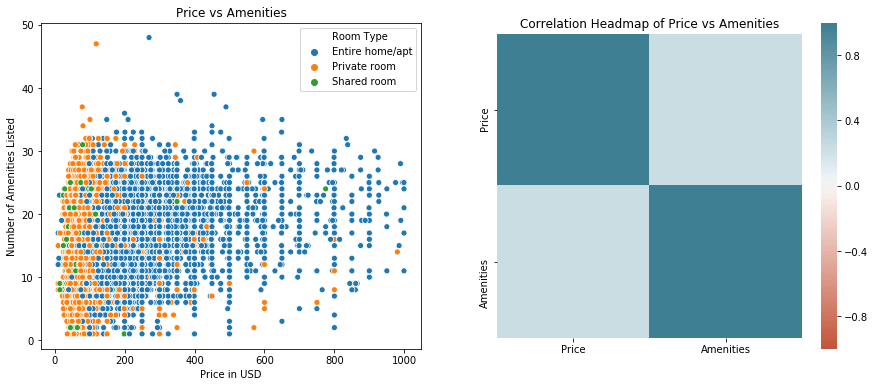

```python
#Correlations and Subplots for Price vs Amenities

#subplot settings
fig, axes = plt.subplots(ncols=2,figsize=(15,6))

#fig.tight_layout()
fig.subplots_adjust(hspace=2)

#correlation matrix


df1=df_plot[["Price","Amenities"]]
corr_matrix = df1.corr()


#scatterplot

sns.scatterplot(y="Amenities", x="Price", hue="Room Type" ,data= df_plot, ax=axes[0])
axes[0].set_title('Price vs Amenities')
axes[0].set_xlabel('Price in USD')
axes[0].set_ylabel('Number of Amenities Listed')

#correlleogram

sns.heatmap(corr_matrix, vmin=-1, vmax=1, center=0,
    cmap=sns.diverging_palette(20, 220, n=200),
    square=True, ax=axes[1])
axes[1].set_title('Correlation Headmap of Price vs Amenities')

print(corr_matrix)
```

### 5.8 Price vs Occupancy

```python
# Price vs Accomodates
df_subset = df_merge[['Neighbourhood Group Cleansed','Property Type','Accommodates','Price']].groupby(['Neighbourhood Group Cleansed','Property Type']).mean()
df_subset
```

| Neighbourhood Group Cleansed | Property Type | Accommodates | Price |
| --- | --- | --- | --- |
| Bronx | Apartment | 2.818182 | 76.000000 |
|  | House | 2.250000 | 57.750000 |
| Brooklyn | Apartment | 2.630058 | 122.248555 |
|  | Condominium | 2.750000 | 116.250000 |
|  | House | 3.260870 | 138.217391 |
|  | Loft | 3.700000 | 155.600000 |
|  | Townhouse | 9.000000 | 284.000000 |
| Manhattan | Apartment | 2.735933 | 162.666065 |
|  | Bed & Breakfast | 2.589286 | 165.196429 |
|  | Boat | 6.000000 | 600.000000 |
|  | Boutique hotel | 2.636364 | 205.727273 |
|  | Bungalow | 6.000000 | 185.000000 |
|  | Cabin | 2.000000 | 250.000000 |
|  | Castle | 1.000000 | 175.000000 |
|  | Condominium | 3.335165 | 286.071429 |
|  | Dorm | 1.666667 | 66.666667 |
|  | Guest suite | 2.500000 | 332.000000 |
|  | Guesthouse | 1.846154 | 85.153846 |
|  | Hostel | 1.000000 | 76.416667 |
|  | House | 4.056872 | 232.483412 |
|  | Hut | 2.000000 | 50.000000 |
|  | Lighthouse | 3.000000 | 221.000000 |
|  | Loft | 3.900415 | 288.746888 |
|  | Other | 2.515152 | 178.868687 |
|  | Serviced apartment | 4.200000 | 420.800000 |
|  | Timeshare | 3.270270 | 343.945946 |
|  | Townhouse | 3.940476 | 228.994048 |
|  | Vacation home | 5.000000 | 529.000000 |
|  | Villa | 4.200000 | 264.000000 |
| Queens | Apartment | 2.385417 | 94.812500 |
|  | Condominium | 4.000000 | 200.000000 |
|  | House | 2.550000 | 73.025000 |
|  | Loft | 3.000000 | 119.500000 |
|  | Townhouse | 6.000000 | 99.000000 |
| Staten Island | Apartment | 4.000000 | 87.000000 |
|  | House | 3.000000 | 125.000000 |

```python
df_merge.columns
```

```
Index(['ID', 'Host Year', 'Host Response Hours', 'Neighbourhood Cleansed',
       'Neighbourhood Group Cleansed', 'Accommodates', 'Bathrooms', 'Bed Type',
       'Bedrooms', 'Beds',
       ...
       'Wireless Internet', 'translation missing: en.hosting_amenity_49',
       'translation missing: en.hosting_amenity_50', 'Host Has Profile Pic',
       'Host Identity Verified', 'Host Is Superhost', 'Instant Bookable',
       'Is Location Exact', 'Require Guest Phone Verification',
       'Require Guest Profile Picture'],
      dtype='object', length=130)
```

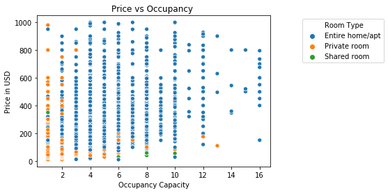

```python
sns.scatterplot(x="Accommodates", y="Price", hue="Room Type" ,data= df_merge)

plt.title('Price vs Occupancy ')
plt.xlabel('Occupancy Capacity')
plt.ylabel('Price in USD')
plt.legend(loc='upper right', bbox_to_anchor=(1.5,1))
```

## 6. Conclusion of Exploratory Data Analysis

### Challenges :

- The greatest influence of Price of a property is the season and location.
- Holiday seasons, always see a high rise in prices
- Location plays a major role as well in terms to determine the price. For instance, a riverside property will be more expensive than an inland property.
- The relationship of price with most of the features is non-linear.

Therefore the greatest challenge of the analysis is lack of seasonal data. However, in this analysi we attempt to estimate the price of a property based on its features and ratings.

## References :

1. Data Cleaning
   - https://stackoverflow.com/questions/41244981/extract-comma-separated-values-to-individual-rows-in-pandas
   - https://stackoverflow.com/questions/28654047/pandas-convert-some-columns-into-rows
   - https://stackoverflow.com/questions/10373660/converting-a-pandas-groupby-output-from-series-to-dataframe
1. Plots
   - https://pandas.pydata.org/pandas-docs/stable/user_guide/visualization.html